# class_14_samplingVariance_ColinAyres.Rmd

Colin Ayres

2024-12-05

# Sampling distribution of mean exercises (**solutions**)

## Exercise 1

- Assuming that IQ is normally distributed with $\mu = 100$ and $\sigma = 15$ what is the probability of drawing a random sample with:
  - $N=25$ and $\bar{X} > 130$
  - $N=25$ and $\bar{X}$ between 85 and 115?
  - $N=25$ and $\bar{X}$ between 95 and 105?
- How does decreasing the sample size to 10 affects these probabilities?
- Try making your own guesses before checking with *R*!

## Solution to Ex.1

```r
mu <- 100; sigma <- 15; n <- 25
pnorm(130, mu, sigma / sqrt(n), lower.tail=F)
```

```
## [1] 7.619853e-24
```

```r
all.equal(0,
    pnorm(130, mu, sigma / sqrt(n), lower.tail=F))
```

```
## [1] TRUE
```

```r
# Above checks if it's zero
pnorm(115, mu, sigma / sqrt(n)) -
    pnorm(85, mu, sigma / sqrt(n))
```

```
## [1] 0.9999994
```

```r
pnorm(105, mu, sigma / sqrt(n)) -
    pnorm(95, mu, sigma / sqrt(n))
```

```
## [1] 0.9044193
```

```
## [1] 1.269814e-10
```

```
## [1] 0.9984346
```

```
## [1] 0.7081595
```

## Exercise 2

- Assuming that IQ is normally distributed with $\mu = 100$ and $\sigma = 15$ and you draw a random sample of 50 people, what is the range of values around $\mu$ that your sample mean will fall in with the probability of 95%?

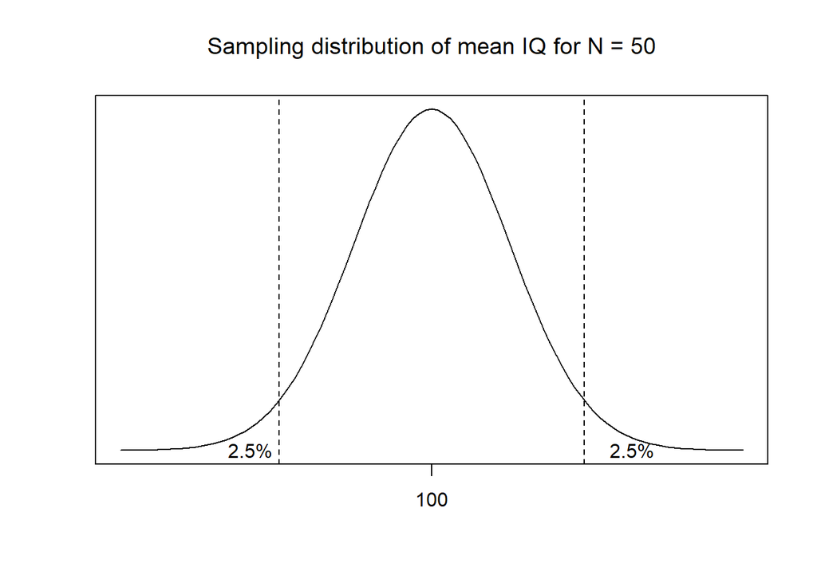

```r
curve(dnorm, -4, 4, xaxt="n", yaxt="n", xlab="", ylab="",
main=expression("Sampling distribution of mean IQ for N = 50"))
axis(1, 0, "100")
abline(v = qnorm(c(.025, .975)), lty=2)
text(qnorm(c(.01, .995)), 0, "2.5%")
```

## Solution to Ex.2

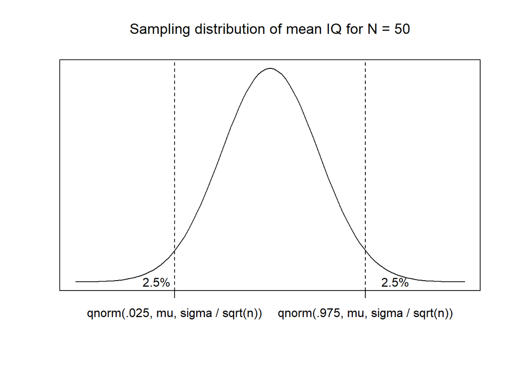

```r
n <- 50
curve(dnorm, -4, 4, xaxt="n", yaxt="n", xlab="", ylab="",
main=expression("Sampling distribution of mean IQ for N = 50"))
axis(1, qnorm(c(.025, .975)),
     c("qnorm(.025, mu, sigma / sqrt(n))", "qnorm(.975, mu, sigma / sqrt(n))"))
abline(v = qnorm(c(.025, .975)), lty=2)
text(qnorm(c(.01, .995)), 0, "2.5%")
```

## Solution to Ex.2 (and *Z* distribution)

```r
qnorm(.025, mu, sigma / sqrt(n))
```

```
## [1] 95.84229
```

```r
mu + qnorm(.025) * sigma / sqrt(n)
```

```
## [1] 95.84229
```

```r
qnorm(.975, mu, sigma / sqrt(n))
```

```
## [1] 104.1577
```

```r
mu + qnorm(.975) * sigma / sqrt(n)
```

```
## [1] 104.1577
```

- $Z$ scores are centred around zero, so:

```r
mu + qnorm(.025) * sigma / sqrt(n)
```

```
## [1] 95.84229
```

```r
mu - qnorm(.025) * sigma / sqrt(n)
```

```
## [1] 104.1577
```

## Exercise 3

- Assuming that IQ is normally distributed with $\mu = 100$ and $\sigma = 15$ how many people do you need to sample at random to have at least 95% chances that their mean will fall between 95 and 105?

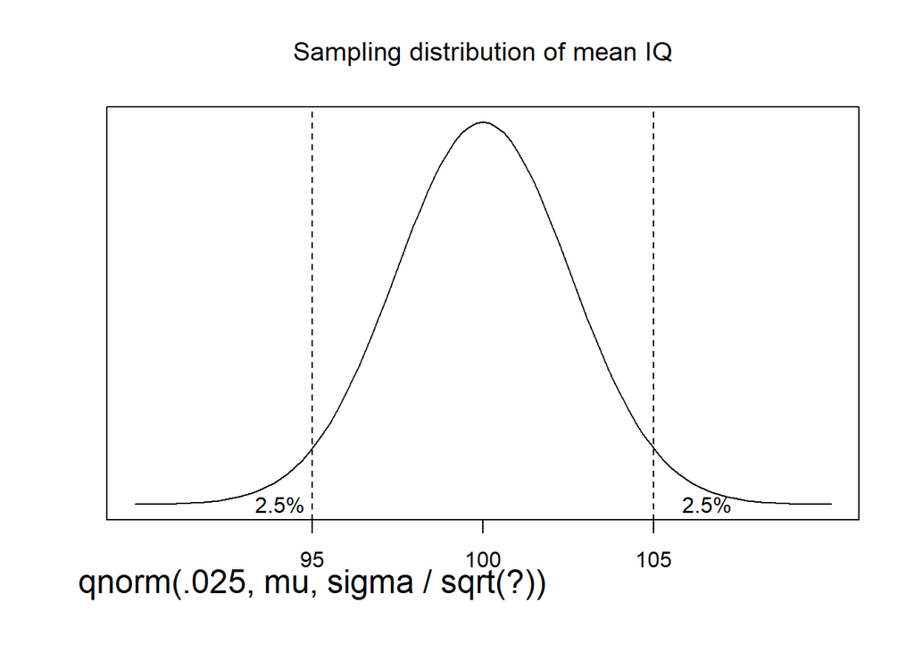

```r
curve(dnorm, -4, 4, xaxt="n", yaxt="n", xlab="", ylab="",
main=expression("Sampling distribution of mean IQ"))
axis(1, qnorm(c(.025, .5, .975)), c("95", "100", "105"))
axis(1, qnorm(c(.025, .975)),
     c("qnorm(.025, mu, sigma / sqrt(?))", "qnorm(.975, mu, sigma / sqrt(?))"),
     line=1,  lty=0, cex.axis=1.5)
abline(v = qnorm(c(.025, .975)), lty=2)
text(qnorm(c(.01, .995)), 0, "2.5%")
```

## $Z$-based solution

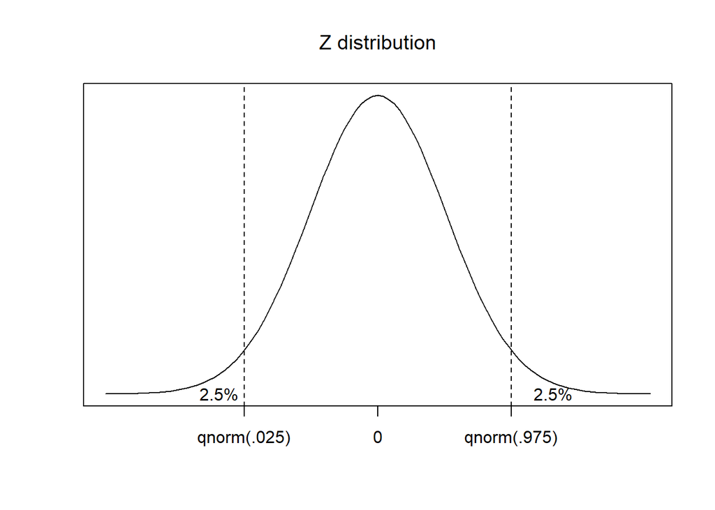

```r
curve(dnorm, -4, 4, xaxt="n", yaxt="n", xlab="", ylab="",
main=expression("Z distribution"))
axis(1, qnorm(c(.025, .5, .975)),
     c("qnorm(.025)", "0", "qnorm(.975)"))
abline(v = qnorm(c(.025, .975)), lty=2)
text(qnorm(c(.01, .995)), 0, "2.5%")
```

- $Z = \frac{\bar{X} - \mu}{\sigma} * \sqrt{N}$
- `qnorm(.975)` $= \frac{105 - 100}{15} * \sqrt{N}$

```r
ceiling((qnorm(.975)*15/5)^2)
```

```
## [1] 35
```

# Sampling distribution of variance

## Sampling distribution of variance

$\hat{\sigma}^2 = \frac{1}{N}\sum{(X_i - \bar{X})^2}$

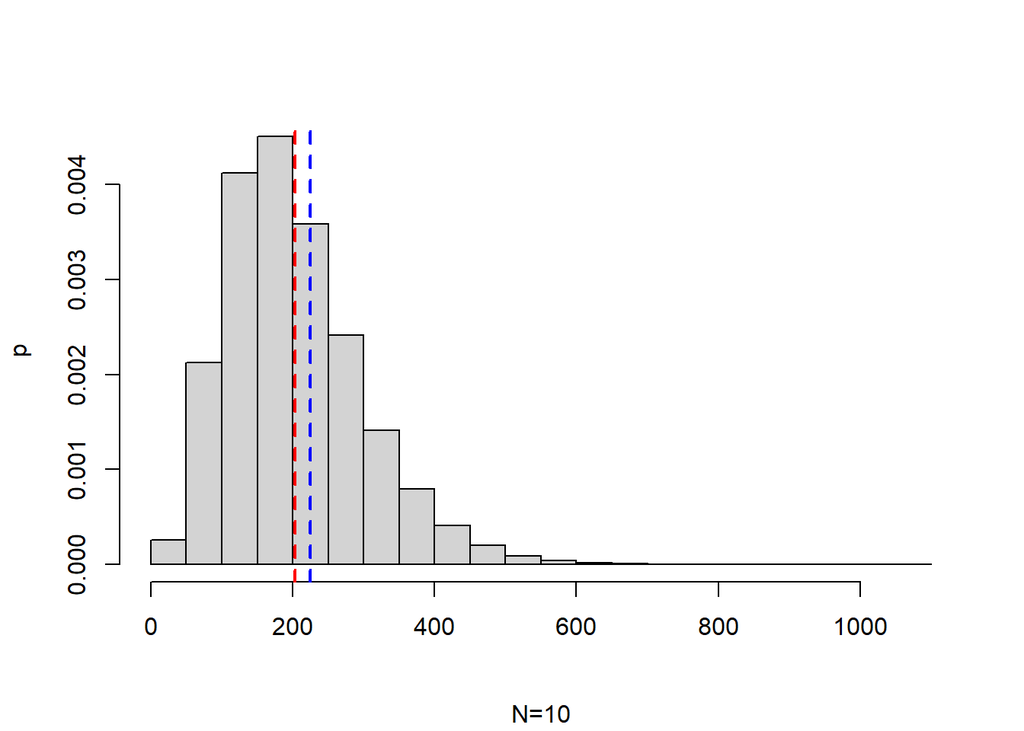

```r
i <- 100000
n <- 10; mu <- 100; sigma <- 15
variance <- function(x) mean((x - mean(x))^2)

samp <- replicate(i, variance(rnorm(n, mu, sigma)))
hist(samp, prob=TRUE, main="",
     sub="N=10", xlab="", ylab="p")
abline(v = mean(samp), lty=2, lwd=2, col="red")
abline(v = sigma^2, lty=2, lwd=2, col="blue")
```

- right-skewed
  - but asymptotically normal ($N \to \infty$)
- red: mean of sampling distribution
- blue: true value of population variance
  - systematically underestimated

## Sample variance bias (1)

- Population mean: $\mu = \frac{1}{N_{pop}}\sum{X_i}$
- Sample estimate: $\hat{\mu} = \bar{X} = \frac{1}{N_{samp}}\sum{X_i}$
- If $N_{samp}$ drawn randomly and independently, estimation error zeroes on average
- Population variance: $\sigma^2 = \frac{1}{N_{pop}}\sum{(X_i - \mu)^2}$
- Sample estimate: $\hat{\sigma}^2 = \frac{1}{N_{samp}}\sum{(X_i - \bar{X})^2}$
- $\sum{(X_i - \bar{X})^2} \leqslant \sum{(X_i - c)^2}$ for any $c$
  - just like $\sum{|(X_i - Med)|} \leqslant \sum{|(X_i - c)|}$ for any $c$

## Bessel’s correction

- Check out [Wikipedia on Bessel’s correction](https://en.wikipedia.org/wiki/Bessel%27s_correction)
- Sample estimate of variance: $\hat{\sigma}^2 = \frac{1}{df}\sum{(X_i - \bar{X})^2}$
- Degrees of freedom: $df = N - 1$
  - $\sigma^2 = \frac{1}{N_{samp}-1}\sum{(X_i - \bar{X})^2}$

## Degrees of freedom

- Estimation based on random sample
- Random, i.e., equal chances for each population element
- Each sample element = *degree of freedom*
  - $df = N$
- Mean estimation:
  - $\bar{X} = \frac{1}{N}\sum{X_i}$
  - $\hat{\mu} = \frac{1}{df}\sum{X_i}$
- Variance estimation (*unbiased*):
  - One d.f. lost for mean estimation
  - Once we assume $\bar{X}$, only $N-1$ elements can vary freely
  - In *R*: `var()`, `sd()`
- In general: estimating a parameter “costs” 1 d.f.

## Variance sampling distribution exercises

- Mean minimises sum of squared deviations
  - Check $\sum{(X_i - \bar{X})^2} \leqslant \sum{(X_i - Med)^2}$ drawing a random sample “infinitely” many times
- Plot histograms of simulated sampling distributions of variance with $N$ vs $N-1$ as denominators
  - single plot, different colours
- Use a simulated sampling distribution to check if variance with $N-1$ is an unbiased estimator